# Import Basic Libraries

```python
import pandas as pd
import numpy as np
import matplotlib.pyplot as plt
```

```python
#Load the dataset
df=pd.read_csv('adult.csv')
```

```python
df.head()
```

|  | age | workclass | fnlwgt | education | education-num | marital-status | occupation | relationship | race | sex | capital-gain | capital-loss | hours-per-week | country | salary |
| --- | --- | --- | --- | --- | --- | --- | --- | --- | --- | --- | --- | --- | --- | --- | --- |
| 0 | 39 | State-gov | 77516 | Bachelors | 13 | Never-married | Adm-clerical | Not-in-family | White | Male | 2174 | 0 | 40 | United-States | <=50K |
| 1 | 50 | Self-emp-not-inc | 83311 | Bachelors | 13 | Married-civ-spouse | Exec-managerial | Husband | White | Male | 0 | 0 | 13 | United-States | <=50K |
| 2 | 38 | Private | 215646 | HS-grad | 9 | Divorced | Handlers-cleaners | Not-in-family | White | Male | 0 | 0 | 40 | United-States | <=50K |
| 3 | 53 | Private | 234721 | 11th | 7 | Married-civ-spouse | Handlers-cleaners | Husband | Black | Male | 0 | 0 | 40 | United-States | <=50K |
| 4 | 28 | Private | 338409 | Bachelors | 13 | Married-civ-spouse | Prof-specialty | Wife | Black | Female | 0 | 0 | 40 | Cuba | <=50K |

# Data cleaning

```python
#check for null values
df.isnull().sum().sum()
```

```
0
```

```python
df.columns
```

```
Index(['age', 'workclass', 'fnlwgt', 'education', 'education-num',
       'marital-status', 'occupation', 'relationship', 'race', 'sex',
       'capital-gain', 'capital-loss', 'hours-per-week', 'country', 'salary'],
      dtype='object')
```

```python
df['salary'].unique()
```

```
array([' <=50K', ' >50K'], dtype=object)
```

```python
df.groupby('salary').mean()
```

| salary | age | fnlwgt | education-num | capital-gain | capital-loss | hours-per-week |
| --- | --- | --- | --- | --- | --- | --- |
| <=50K | 36.783738 | 190340.86517 | 9.595065 | 148.752468 | 53.142921 | 38.840210 |
| >50K | 44.249841 | 188005.00000 | 11.611657 | 4006.142456 | 195.001530 | 45.473026 |

```python
df.describe().T
```

|  | count | mean | std | min | 25% | 50% | 75% | max |
| --- | --- | --- | --- | --- | --- | --- | --- | --- |
| age | 32561.0 | 38.581647 | 13.640433 | 17.0 | 28.0 | 37.0 | 48.0 | 90.0 |
| fnlwgt | 32561.0 | 189778.366512 | 105549.977697 | 12285.0 | 117827.0 | 178356.0 | 237051.0 | 1484705.0 |
| education-num | 32561.0 | 10.080679 | 2.572720 | 1.0 | 9.0 | 10.0 | 12.0 | 16.0 |
| capital-gain | 32561.0 | 1077.648844 | 7385.292085 | 0.0 | 0.0 | 0.0 | 0.0 | 99999.0 |
| capital-loss | 32561.0 | 87.303830 | 402.960219 | 0.0 | 0.0 | 0.0 | 0.0 | 4356.0 |
| hours-per-week | 32561.0 | 40.437456 | 12.347429 | 1.0 | 40.0 | 40.0 | 45.0 | 99.0 |

```python
df['workclass'].value_counts()
```

```
 Private             22696
 Self-emp-not-inc     2541
 Local-gov            2093
 ?                    1836
 State-gov            1298
 Self-emp-inc         1116
 Federal-gov           960
 Without-pay            14
 Never-worked            7
Name: workclass, dtype: int64
```

**Maximum people are working in Private sector**

```python
df['education'].value_counts()
```

```
 HS-grad         10501
 Some-college     7291
 Bachelors        5355
 Masters          1723
 Assoc-voc        1382
 11th             1175
 Assoc-acdm       1067
 10th              933
 7th-8th           646
 Prof-school       576
 9th               514
 12th              433
 Doctorate         413
 5th-6th           333
 1st-4th           168
 Preschool          51
Name: education, dtype: int64
```

**Maximum people has done their High School**

```python
df['marital-status'].value_counts()
```

```
 Married-civ-spouse       14976
 Never-married            10683
 Divorced                  4443
 Separated                 1025
 Widowed                    993
 Married-spouse-absent      418
 Married-AF-spouse           23
Name: marital-status, dtype: int64
```

**Maximum people are married with civilian spouse**

```python
df['relationship'].value_counts()
```

```
 Husband           13193
 Not-in-family      8305
 Own-child          5068
 Unmarried          3446
 Wife               1568
 Other-relative      981
Name: relationship, dtype: int64
```

**Maximum people are Husband who are working**

```python
df['sex'].value_counts()
```

```
 Male      21790
 Female    10771
Name: sex, dtype: int64
```

**No. of males is twice than females**

```python
df['occupation'].value_counts()
```

```
 Prof-specialty       4140
 Craft-repair         4099
 Exec-managerial      4066
 Adm-clerical         3770
 Sales                3650
 Other-service        3295
 Machine-op-inspct    2002
 ?                    1843
 Transport-moving     1597
 Handlers-cleaners    1370
 Farming-fishing       994
 Tech-support          928
 Protective-serv       649
 Priv-house-serv       149
 Armed-Forces            9
Name: occupation, dtype: int64
```

**Maximum people has occupation as prof-speciality(professor in a perticular subject )**

**There are very less people who are in Armed forces**

```python
df['country'].value_counts()
```

```
 United-States                 29170
 Mexico                          643
 ?                               583
 Philippines                     198
 Germany                         137
 Canada                          121
 Puerto-Rico                     114
 El-Salvador                     106
 India                           100
 Cuba                             95
 England                          90
 Jamaica                          81
 South                            80
 China                            75
 Italy                            73
 Dominican-Republic               70
 Vietnam                          67
 Guatemala                        64
 Japan                            62
 Poland                           60
 Columbia                         59
 Taiwan                           51
 Haiti                            44
 Iran                             43
 Portugal                         37
 Nicaragua                        34
 Peru                             31
 Greece                           29
 France                           29
 Ecuador                          28
 Ireland                          24
 Hong                             20
 Cambodia                         19
 Trinadad&Tobago                  19
 Thailand                         18
 Laos                             18
 Yugoslavia                       16
 Outlying-US(Guam-USVI-etc)       14
 Hungary                          13
 Honduras                         13
 Scotland                         12
 Holand-Netherlands                1
Name: country, dtype: int64
```

**No. of employment in united satate is maximum than other countries**

```python
#Filling ?
df['workclass']=df['workclass'].replace(' ?','private')
df['country']=df['country'].replace(' ?','United-States')
df['occupation']=df['occupation'].replace(' ?','prof-spaciality')
```

# Feature engineering

```python
df.education=df.education.replace([' Preschool',' 1st-4th',' 5th-6th',' 7th-8th',' 9th',' 10th',' 11th',' 12th',],'School')
df.education=df.education.replace(' HS-grad','High-School')
df.education=df.education.replace([' Assoc-acdm',' Assoc-voc',' Some-college',' Prof-school'],'Higher')
df.education=df.education.replace(' Bachelors','Graduates')
df.education=df.education.replace(' Doctorate','Doc')
```

```python
df['education'].unique()
```

```
array(['Graduates', 'High-School', 'School', ' Masters', 'Higher', 'Doc'],
      dtype=object)
```

```python
df['marital-status']=df['marital-status'].replace([' Married-spouse-absent',' Married-civ-spouse',' Married-AF-spouse'],'married')
df['marital-status']=df['marital-status'].replace([' Divorced',' Separated',' Widowed'],'others')
```

```python
df['marital-status'].unique()
```

```
array([' Never-married', 'married', 'others'], dtype=object)
```

```python
#what is the marital status whose working hour per week is maximum
df.groupby(['marital-status'])['hours-per-week'].mean()
```

```
marital-status
 Never-married    36.939998
married           43.183628
others            39.667544
Name: hours-per-week, dtype: float64
```

# Visualization

```python
import matplotlib.pyplot as plt
import seaborn as sns
```

# Which sex category is earning greater than 50k

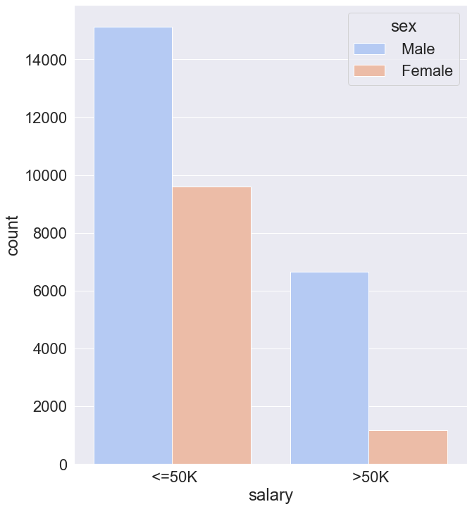

```python
plt.figure(figsize=(10,12))
sns.set(font_scale=2)
sns.countplot(df['salary'],palette='coolwarm',hue='sex',data=df)
plt.show()
```

**No. of males are earning more than 50k than Females**

# Which type of people in race are earning more than others

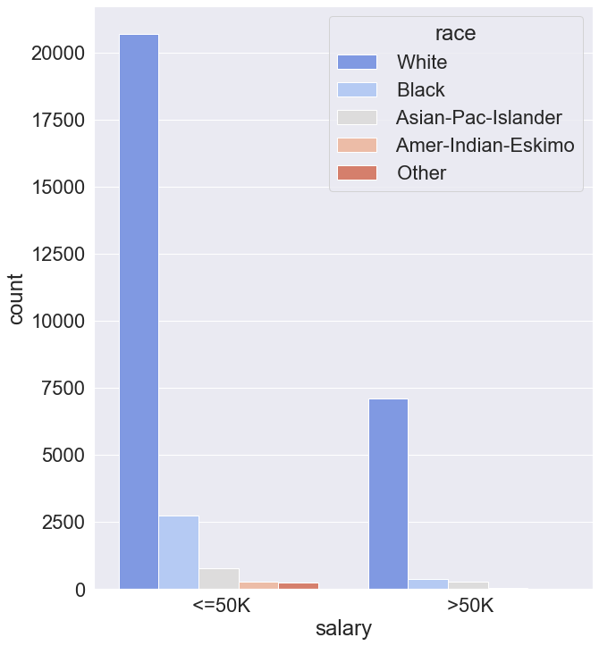

```python
plt.figure(figsize=(10,12))
sns.set(font_scale=2)
sns.countplot(df['salary'],palette='coolwarm',hue='race',data=df)
plt.show()
```

**No. of White people are earning more salary than others**

# What is the relationship of people who is earning more than 50k

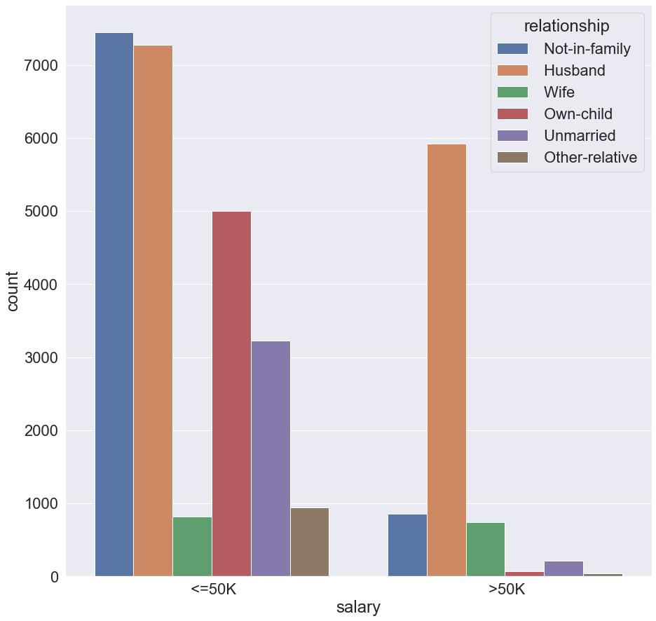

```python
plt.figure(figsize=(15,15))
sns.set(font_scale=2)
sns.countplot(df['salary'],hue='relationship',data=df);
```

# finding the correlation among all the numerical variables

```python
df.corr()
```

|  | age | fnlwgt | education-num | capital-gain | capital-loss | hours-per-week |
| --- | --- | --- | --- | --- | --- | --- |
| age | 1.000000 | -0.076646 | 0.036527 | 0.077674 | 0.057775 | 0.068756 |
| fnlwgt | -0.076646 | 1.000000 | -0.043195 | 0.000432 | -0.010252 | -0.018768 |
| education-num | 0.036527 | -0.043195 | 1.000000 | 0.122630 | 0.079923 | 0.148123 |
| capital-gain | 0.077674 | 0.000432 | 0.122630 | 1.000000 | -0.031615 | 0.078409 |
| capital-loss | 0.057775 | -0.010252 | 0.079923 | -0.031615 | 1.000000 | 0.054256 |
| hours-per-week | 0.068756 | -0.018768 | 0.148123 | 0.078409 | 0.054256 | 1.000000 |

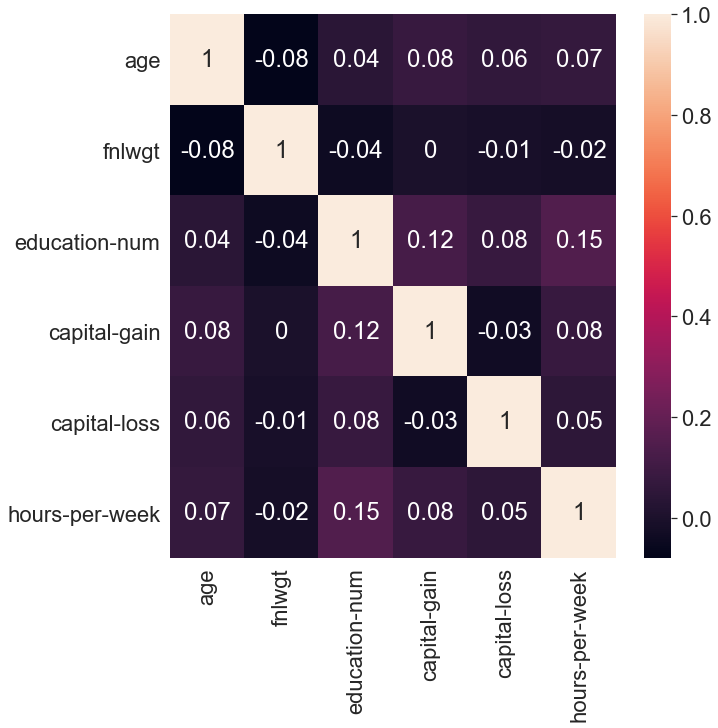

```python
plt.figure(figsize=(10,10))
sns.set(font_scale=2)
sns.heatmap(np.round(df.corr(),2),annot=True)
plt.show()
```

# What is the % of education background in the dataset

```python
px.pie(df,values='education-num',names='education',title='% of Education')
```

[interactive chart not shown]

**There are maximum people who had done their higher education**

# Which occupation has maximum salary than other occupations

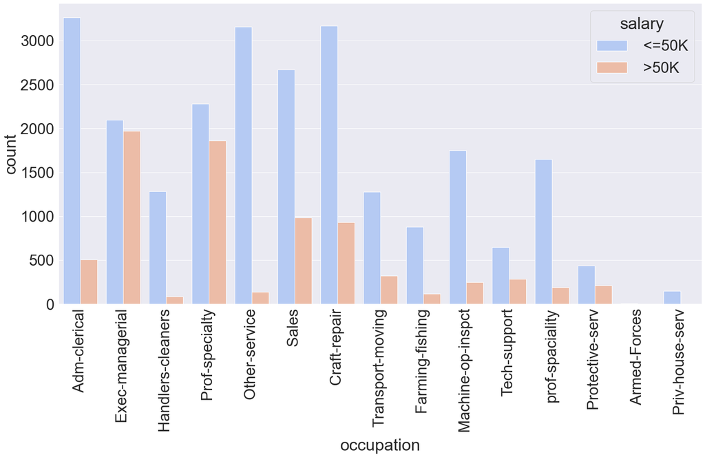

```python
plt.figure(figsize=(25,12))
sns.set(font_scale=3)
sns.countplot(df['occupation'],hue='salary',data=df,palette='coolwarm')
plt.xticks(rotation=90);
```

**There are more People whose job role is Executive-manager is earning more than 50k**

# How the educational background is related with salary

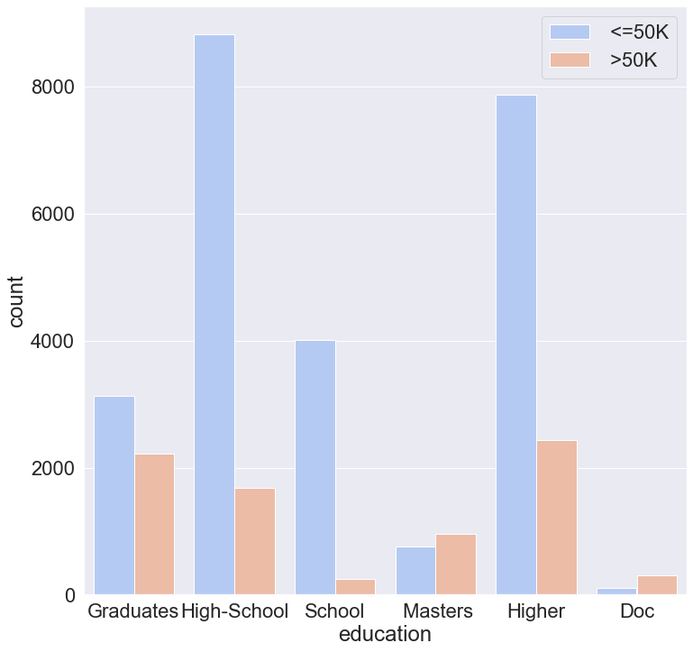

```python
plt.figure(figsize=(12,12))
sns.set(font_scale=2)
sns.countplot(df['education'],hue='salary',data=df,palette='coolwarm')
plt.legend(loc='upper right', bbox_to_anchor=(1, 1.0));
```

**People who are from Higher educational background are earning more**

**people who are from high school educational background are earning less**

# Which gender is more educated

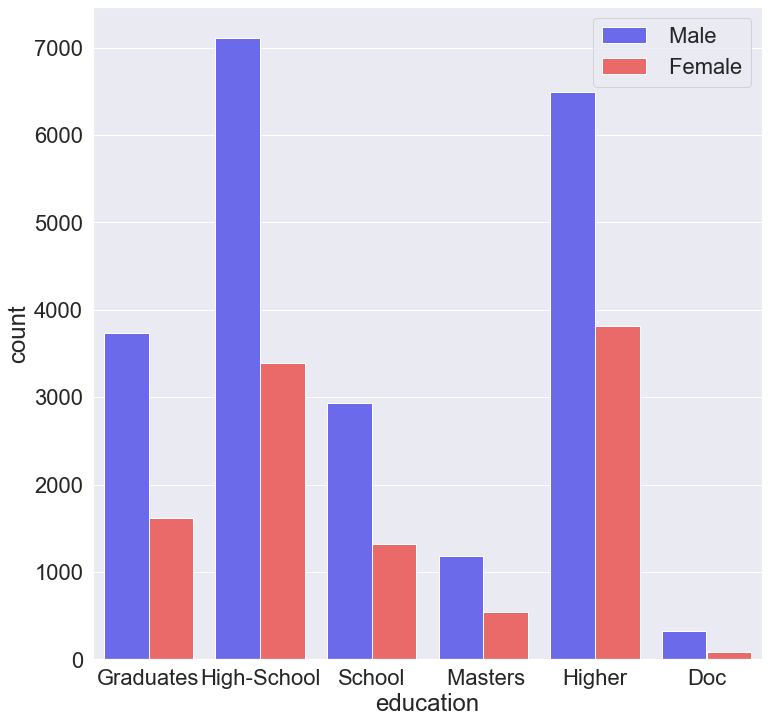

```python
plt.figure(figsize=(12,12))
sns.set(font_scale=2)
sns.countplot(df['education'],hue='sex',data=df,palette='seismic')
plt.legend(loc='upper right', bbox_to_anchor=(1, 1.0));
```

**Males are more educated than Females**

# Which marital status people are earning more

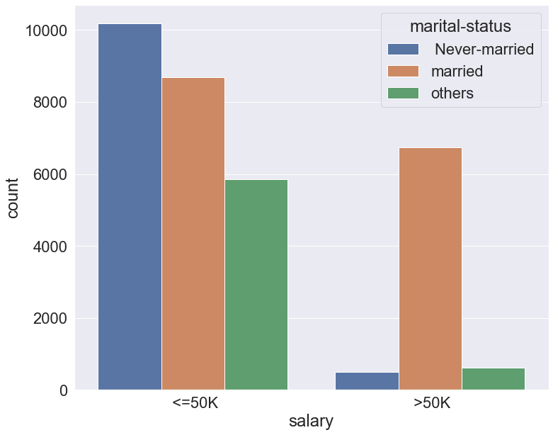

```python
#Salary based on martial status
plt.figure(figsize=(12,10))
sns.countplot('salary',data=df,hue='marital-status')
plt.show()
```

**Married people are earning more**

# Which kind of people have maximum capital loss

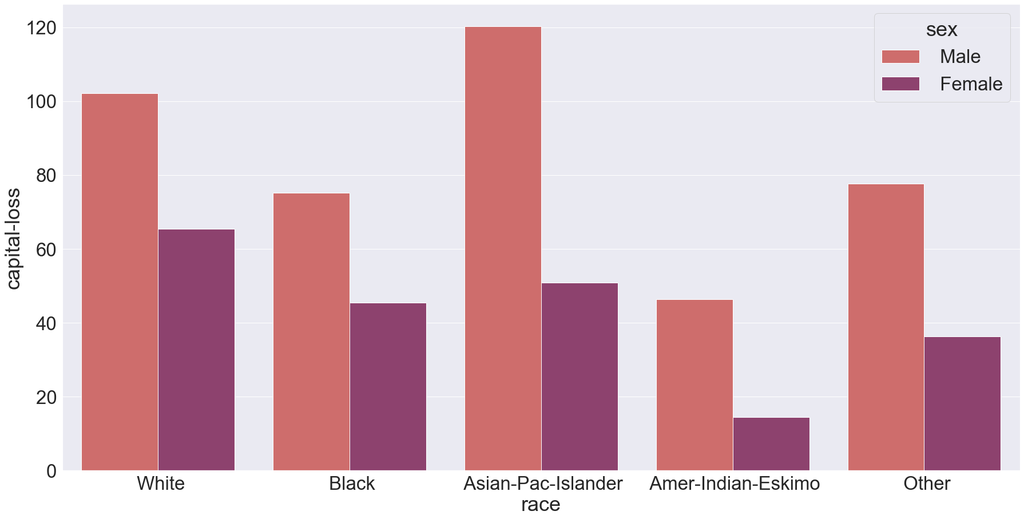

```python
plt.figure(figsize=(30,15))
sns.set(font_scale=3)
sns.barplot(x='race',y='capital-loss',data=df,hue='sex',palette='flare',ci=None)
plt.show()
```

**Asian-Pac-islander people have more capital loss than others**